# Final Project

## How to Pass BIOL 1620: An analysis of the Fall 2017 Grades

### Purpose

The purpose of this analysis is to use the student grade data from Fall 2017 to determine the best practices and score requirements to recieve a good grade.

#### Sources

The raw data used in this analysis was obtained directly from Dr. Zahn on **1/24/2018**. That data along with the raw code used in this analysis will accompany the report in one delivered file.

#### Methodology Notes

Several noteworthy assumptions were made

- It is assumed that the goal of every student is to recieve the best grade possible. Each model treats these results as “positive” and others as “negative”.
- Since the purpose was to help future students improve their grade, only variables within a student’s control were considered(Year taken, but not declared major, etc.)
- Since this analysis operates only with grade and basic student data, it assumes that the large sample size will account for other variables, such as personal and family characteristics.
- When considering grade as a sum of points earned, it is obvious that assignments, quizzes, etc would have a statistically significant effect on grade. Therefore, when considering these factors, we will either explore them on a comparitive basis (which has a greater effect) or carefully select an arbitrary score on those areas to consider “good” and test the effectiveness of that score.

### Input and Clean Data

The following method was used to import and format the data, including removing unecessary information and adding useful formats of existing information. Details on the methodology will be discussed in the corresponding section.

```r
info1 = read.csv("~/R/Data_Course/Data_Course_BAYLY/Final_Project/Student_Info_Sec-001.csv")
info2 = read.csv("~/R/Data_Course/Data_Course_BAYLY/Final_Project/Student_Info_Sec-002.csv")
info3 = read.csv("~/R/Data_Course/Data_Course_BAYLY/Final_Project/Student_Info_Sec-003.csv")
grades1 = read.csv("~/R/Data_Course/Data_Course_BAYLY/Final_Project/Student_Grades_Sec-001.csv")
grades2 = read.csv("~/R/Data_Course/Data_Course_BAYLY/Final_Project/Student_Grades_Sec-002.csv")
grades3 = read.csv("~/R/Data_Course/Data_Course_BAYLY/Final_Project/Student_Grades_Sec-003.csv")
data = read.csv("~/R/Data_Course/Data_Course_BAYLY/Final_Project/Section_Info.csv")

names1 = colnames(grades1)
strsplit(names1,"..3", fixed = TRUE) -> names1
map(names1,1) -> names1
colnames(grades1) <- names1

names2 = colnames(grades2)
strsplit(names2,"..3", fixed = TRUE) -> names2
map(names2,1) -> names2
colnames(grades2) <- names2

names3 = colnames(grades3)
strsplit(names3,"..3", fixed = TRUE) -> names3
map(names3,1) -> names3
colnames(grades3) <- names3

grades = bind_rows(grades1,grades2)
grades = bind_rows(grades,grades3)
rm(grades1)
rm(grades2)
rm(grades3)

names1 = colnames(info1)
strsplit(names1,"..3", fixed = TRUE) -> names1
map(names1,1) -> names1
colnames(info1) <- names1

names2 = colnames(info2)
strsplit(names2,"..3", fixed = TRUE) -> names2
map(names2,1) -> names2
colnames(info2) <- names2

names3 = colnames(info3)
strsplit(names3,"..3", fixed = TRUE) -> names3
map(names3,1) -> names3
colnames(info3) <- names3


info = bind_rows(info1,info2)
info = bind_rows(info,info3)
rm(info1)
rm(info2)
rm(info3)
rm(names1)
rm(names2)
rm(names3)
info[which(info$ID %in% grades$SIS.Login.ID),] -> info
grades[,grep(colnames(grades), pattern = "Current")] = NULL
grades$Pre..Post.Tests.Final.Points = NULL
grades[,grep(colnames(grades), pattern = "Assignments.Final")] = NULL
grades$Quizzes.Final.Points = NULL
grades$Section [grades$Section == "BIOL-1620-001"] <- "001"
grades$Section [grades$Section == "BIOL-1620-002"] <- "002"
grades$Section [grades$Section == "BIOL-1620-003"] <- "003"
grades$Section = as.integer(grades$Section)
grades[is.na(grades)] <- 0
colnames(grades)[1] <- "ID"
info$CRN = NULL
info$TERM = NULL
info$CRS = NULL
info$SUBJ = NULL
info$CONFID = NULL
info$SEC = NULL
info$LEVL = NULL
info = info [,c(1:4)]

grades$Letter = "X"
grades$color = "x"
    for(i in 1:length(grades$Letter)){

      if(grades$Final.Points[i] >= 600){
        grades$Letter[i] <- "A"
        grades$color[i] <- "green"
      }
      if(grades$Final.Points[i] %in% c(540:599)){
        grades$Letter[i] <- "B"
        grades$color[i] <- "yellow"
      }
      if(grades$Final.Points[i] %in% c(480:539)){
        grades$Letter[i] <- "C"
        grades$color[i] <- "blue"
      }
      if(grades$Final.Points[i] %in% c(400:479)){
        grades$Letter[i] <- "D"
        grades$color[i] <- "pink"
      }
      if(grades$Final.Points[i] < 400){
        grades$Letter[i] <- "E"
        grades$color[i] <- "red"
      }
    }


full = merge(grades,info,by = "ID")

for (i in 1:length(full$Letter)){
  if (full$Your.Choice.Final.Points[i] > 100){
    full$Extra[i] = "Extra"
  }
  if (full$Your.Choice.Final.Points[i] == 100) {
    full$Extra[i] = "100"
  }
  if (full$Your.Choice.Final.Points[i] < 100){
    full$Extra[i] = "Less"
  }
  if (full$Your.Choice.Final.Points[i] == 150){
    full$Extra[i] = "Full"
  }
}

full$Extra = as.factor(full$Extra)

full$Quiz.average = full$Quizzes.Final.Score/10

for (i in 1:length(full$Quiz.average)){
  if (full$Quiz.average[i] <= 10 && full$Quiz.average[i] >= 9.0){ full$Quiz.average[i] = 10 }
  if (full$Quiz.average[i] <= 8.9 && full$Quiz.average[i] >= 7.0){ full$Quiz.average[i] = 8 }
  if (full$Quiz.average[i] <= 6.9 && full$Quiz.average[i] >= 5.0){ full$Quiz.average[i] = 6 }
  if (full$Quiz.average[i] <= 4.9 && full$Quiz.average[i] >= 3.0){ full$Quiz.average[i] = 4 }
  if (full$Quiz.average[i] <= 2.9 && full$Quiz.average[i] >= 1.0){ full$Quiz.average[i] = 2 }
  if (full$Quiz.average[i] <= 1 && full$Quiz.average[i] >= 0){ full$Quiz.average[i] = 0 }
}
full$Quiz.average = (full$Quiz.average / 2)
full$Quiz.good = 0

for (i in 1:length(full$Quiz.good)){
  if (full$Quiz.average[i] >= 3){ full$Quiz.good[i] = "Good"}
  if (full$Quiz.average[i] < 3){ full$Quiz.good[i] = "Bad"}
}

full$category = 0

full$category[as.integer(rownames(subset(full, full$Quiz.average >= 3 & full$Extra == "Extra")))] = "great"
full$category[as.integer(rownames(subset(full, full$Quiz.average >= 3 & full$Extra == "Less")))] = "quiz"
full$category[as.integer(rownames(subset(full, full$Quiz.average < 3 & full$Extra == "Extra")))] = "points"
full$category[as.integer(rownames(subset(full, full$Quiz.average < 3 & full$Extra == "Less")))] = "bad"

full$Days = 1
full$Days[which(full$Section == 001 | full$Section == 002)] = 3
full$Days[which(full$Section == 003)] = 2
```

### Analysis and Discussion

#### Final Score vs. Class

Below is a graph comparing Class to Final Score

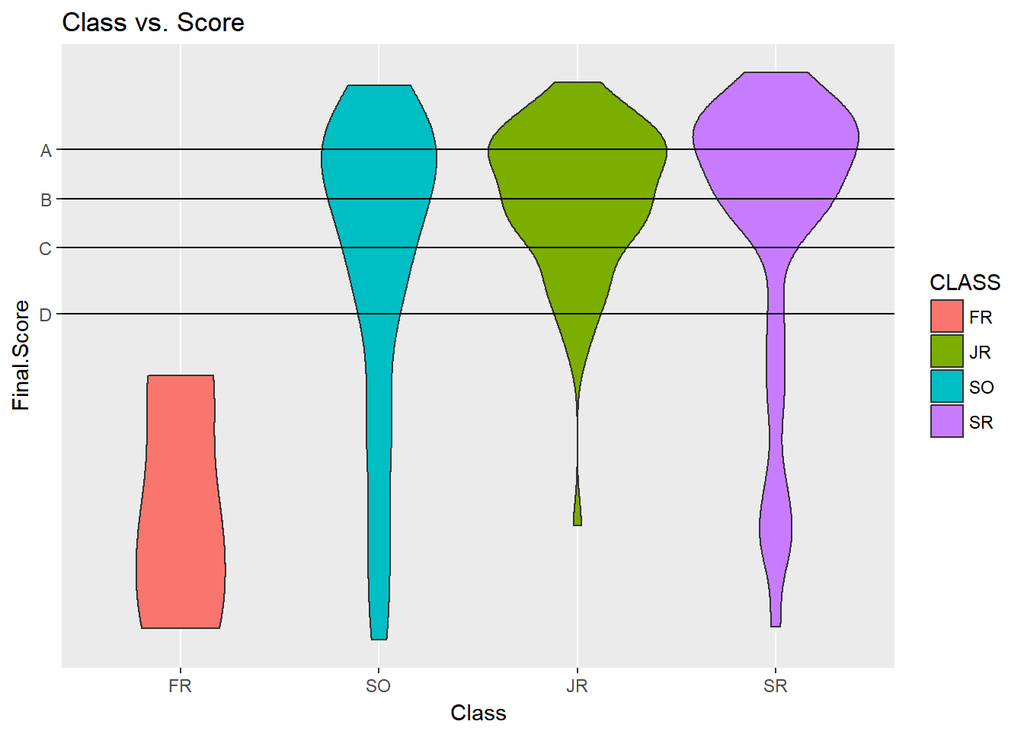

The correlation between a successful grade and college class is clear. Impressively, not one Freshman recieved any grade other than “E”. The significance of these statistics is demonstrated by the following model summary

```r
TukeyHSD(aov(full$Final.Score ~ full$CLASS))
```

```
##   Tukey multiple comparisons of means
##     95% family-wise confidence level
##
## Fit: aov(formula = full$Final.Score ~ full$CLASS)
##
## $`full$CLASS`
##             diff        lwr        upr     p adj
## JR-FR  53.980990  20.378541 87.5834383 0.0002867
## SO-FR  43.310424   9.585098 77.0357509 0.0058013
## SR-FR  49.567424  15.624746 83.5101022 0.0012010
## SO-JR -10.670565 -21.129472 -0.2116586 0.0436284
## SR-JR  -4.413565 -15.553424  6.7262936 0.7330091
## SR-SO   6.257000  -5.248197 17.7621969 0.4938546
```

A minute “P” value when comparing other classes to Freshman demonstrates the significance. Freshman should not take this class.

#### Extra Credit

The class required 100 points of “Your Choice” assignments, but accepted up to 150 points. The following graph compares the final score of students who earned more than the required 100 points (Extra), students who earned the maximum 150 points (Full), students who earned exactly 100 points (100), and students who earned less than the required 100 points (Less).

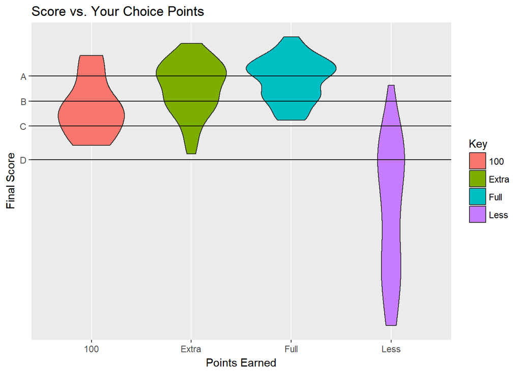

As clearly demonstrated by the graph, failing to at least earn the required 100 points severely impacts a sudent’s ability to earn a successful grade. The average final grade between “Full” and “100” is also significant:

```
## [1] 84.54077
```

```
## [1] 75.01625
```

A difference of almost ten percent in final score is greater than what can be explained by the extra 50 points alone, thus demonstrating a positive correlation between this extra credit and a better score in other areas.

#### Quizzes

The regular quizzes proved to be one of the more difficult parts of the course for many students. So, how many out of 5 does a student need to score in order to recieve a successful grade?

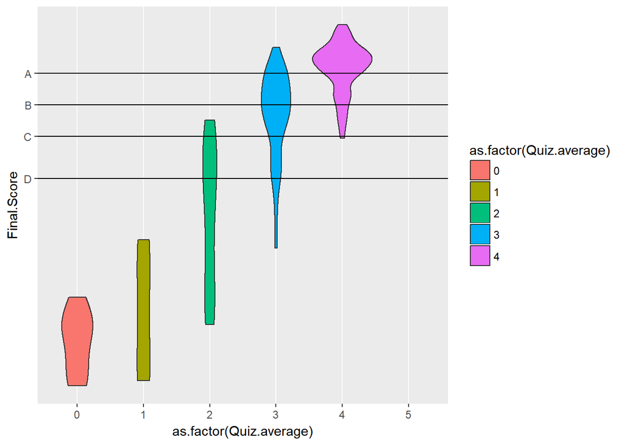

The graph demonstrates a dramatic improvement between an average score of 2 and 3. 3 also happens to be very close to the mean of the average scores across the data. A student should average at least 3 out of 5 on the regular quizzes.

#### Quizzes, or Assignments?

College students always try to find how to get the most benefit out of their time. One large part of the class is studying the textbook and taking regular quizzes on the material. The following graphs compare quiz scores against the already explored “Your Choice” assignments. Ellipses added to each graph deliminates opposing groups in each graph. In these evaluations, a Quiz score of 3 or better is considered “Good”

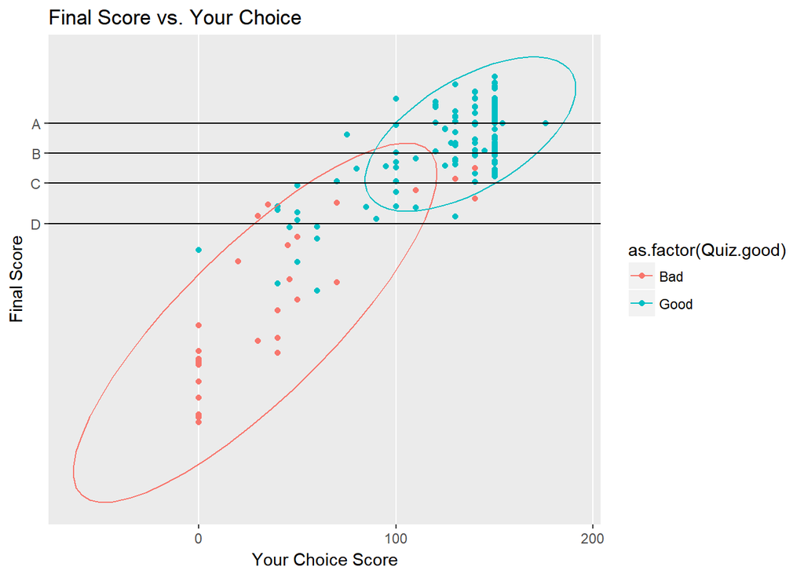

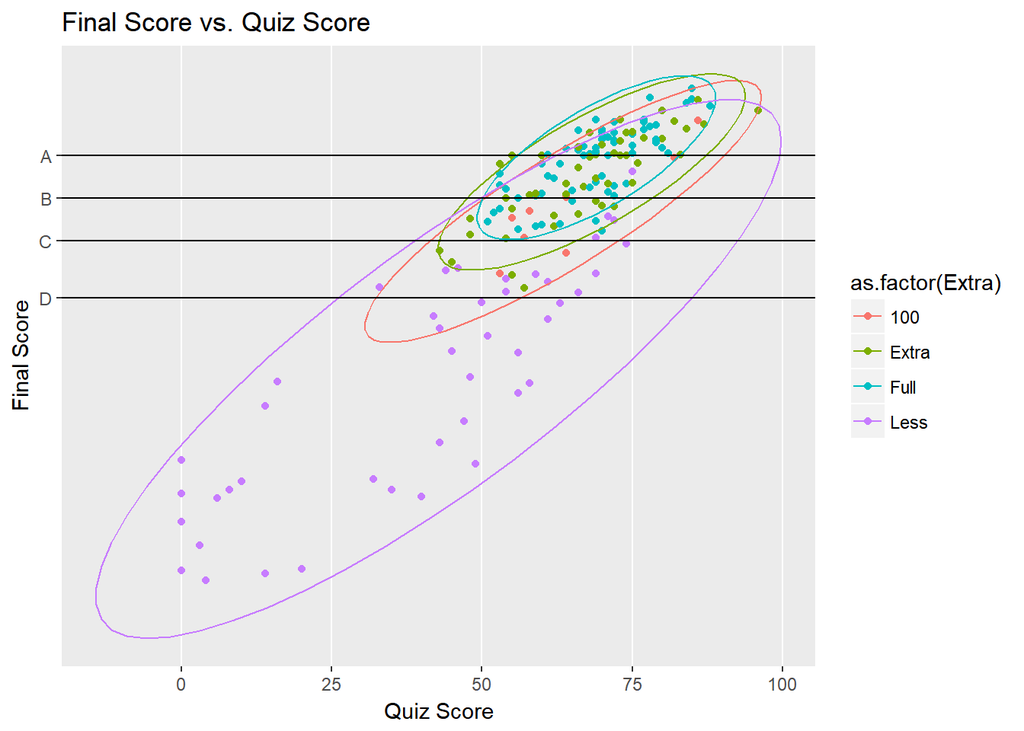

The clustering in the graphs clearly demonstrates a correlatio between each variable and final grade. The following is the same data displayed on a single plot.

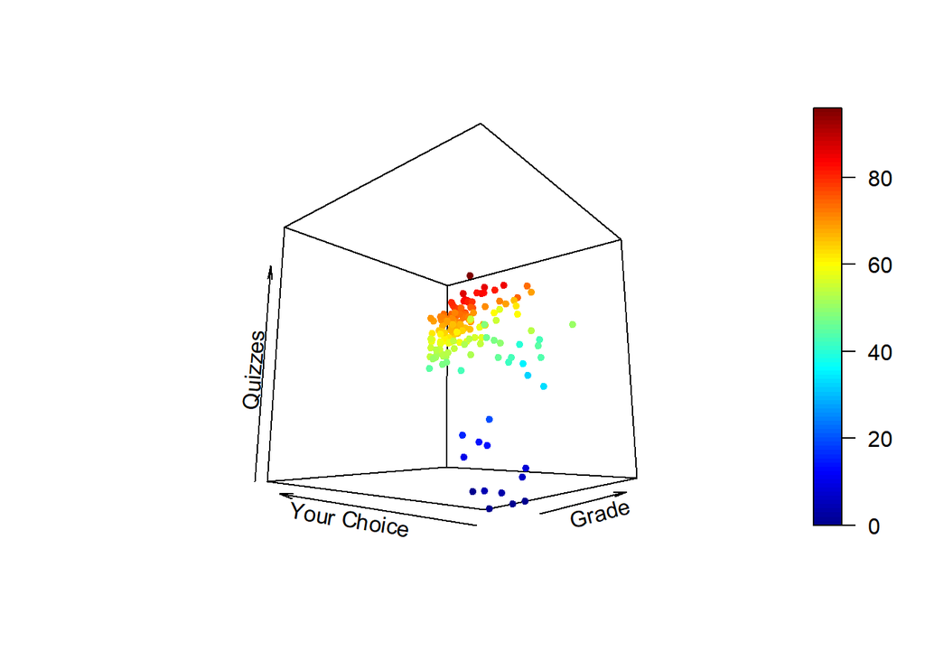

It is difficult to distinguish which variable plays a more significant role. Below is a model summary for their effect on grade

```r
summary.aov(aov(full$Final.Score ~ full$Extra + full$Quiz.good))
```

```
##                 Df Sum Sq Mean Sq F value Pr(>F)
## full$Extra       3  58132   19377  158.92 <2e-16 ***
## full$Quiz.good   1  10528   10528   86.34 <2e-16 ***
## Residuals      161  19631     122
## ---
## Signif. codes:  0 '***' 0.001 '**' 0.01 '*' 0.05 '.' 0.1 ' ' 1
```

The correlation is so strong it requires a more detailed view

```r
summary.aov(aov(full$Final.Score ~ full$Extra + full$Quiz.good))[[1]][["Pr(>F)"]][[1]]
```

```
## [1] 6.597139e-48
```

```r
summary.aov(aov(full$Final.Score ~ full$Extra + full$Quiz.good))[[1]][["Pr(>F)"]][[2]]
```

```
## [1] 1.023761e-16
```

Extra credit on Your Choice assignments plays a more direct role on grade than averaging a 3 on the quizzes.

#### Class Days

During Fall 2017, there were three sections of Biology 1620 taught. Two of those sections (1 and 2) were taught 3 times per week in the afternoon. The third section was taught twice per week in the morning. Because there were only 3 variables, it will be impossible to consider time of day and number of classes per week independently. We will consider them together.

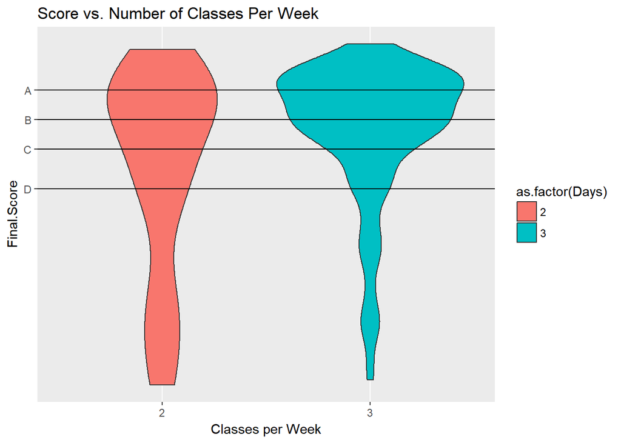

The obvious trend in the graph is affirmed by the model summary

```r
summary.aov(aov(full$Final.Score ~ as.factor(full$Days)))
```

```
##                       Df Sum Sq Mean Sq F value  Pr(>F)
## as.factor(full$Days)   1   3720    3720   7.215 0.00798 **
## Residuals            164  84571     516
## ---
## Signif. codes:  0 '***' 0.001 '**' 0.01 '*' 0.05 '.' 0.1 ' ' 1
```

### Summary

The data revealed many distinct attributes that a successful student is very likely to have. Most interesting was the comparison between Quiz scores and Your Choice assignents. It is encouraging to demonstrate that work serves students best.  
In summary, a student should take the class in the afternoon 3 times per week. They should score 3 or better on the quiz, which should ensure sufficient test results that, when combined with as many “Your Choice” points as possible. If they do those things, they will be extremely like to recieve an “A” or “B” letter grade in the course.